# Lesson1.1

## **Các tham số khác của geom_bar() và geom_col()**

2 hàm này có các thông số của aesthetics (`aes()`) sau:

- alpha: mức độ đậm nhạt
- color: màu sắc (của đường viền bên ngoài của mỗi cột)
- fill: màu sắc của cả cột
- width: kích thước (độ rộng) của cột

3.1. Biểu đồ cột chồng

Khi ta gắn tham số **`fill`** cho một biến phân nhóm, ta sẽ thu được biểu đồ cột chồng.

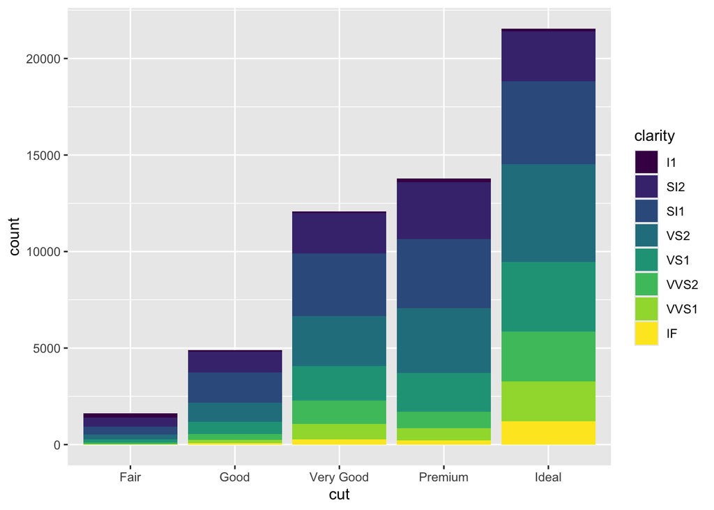

```r
ggplot(data = diamonds) +
  geom_bar(mapping = aes(x = cut, fill = clarity))
```

3.2. Biểu đồ cột ghép

Thêm vào biểu đồ cột chồng ở trên tham số `position = "dodge"`, ta thu được biểu đổ cột ghép.

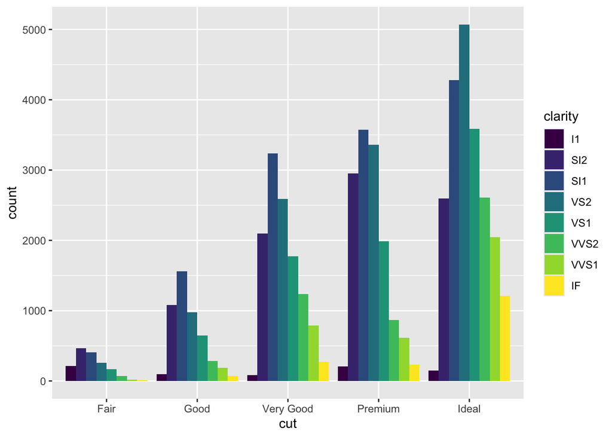

```r
ggplot(data = diamonds) +
  geom_bar(mapping = aes(x = cut, fill = clarity), position = "dodge")
```

*(Nếu đặt `position = "stack"`, ta lại thu được biểu đồ cột chồng như cũ)*

3.3. Biểu đồ miền

Tương tự biểu đồ cột chồng nhưng nếu ta muốn thay trục y bằng tỷ lệ %, nhằm kéo dài mỗi cột ra hết chiều dài trục y. Ta đặt `position = "fill"`

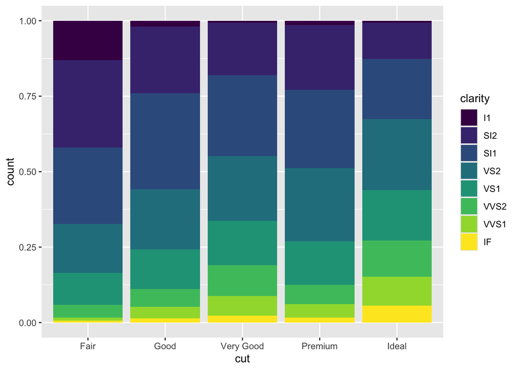

```r
ggplot(data = diamonds) +
  geom_bar(mapping = aes(x = cut, fill = clarity), position = "fill")
```

3.4. Biểu đồ cột ngang

Khi số lượng nhóm của ta quá nhiều gây khó khăn khi trình bày. Biểu đồ cột ngang là sự lựa chọn hợp lý nhất. Bạn chỉ cần thêm hàm `coord_flip()` là đủ.

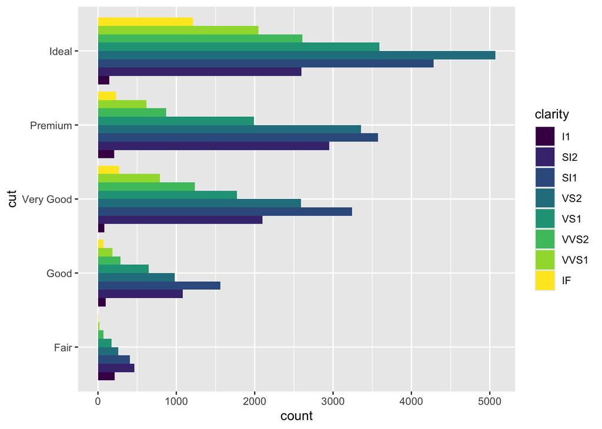

```r
ggplot(data = diamonds) +
  geom_bar(mapping = aes(x = cut, fill = clarity), position = "dodge") +
  coord_flip()
```

4. Biểu đồ quạt (pie chart)

   Đây là biểu đồ không có ý nghĩa trong các báo cáo khoa học vì giá trị của nó không hơn gì một bảng số liệu nhỏ gọn, đơn giản. Ví vậy **ggplot** không hỗ trợ vẽ biểu đồ quạt. Tuy nhiên ta vẫn có mẹo để vẽ được. Bằng các thêm hàm `coord_polar()` vào trong biểu đồ cột.
5. Biểu đồ hộp (box plot)

   **Boxplot** là biểu đồ dùng để mô tả một biến định lượng theo một cách trực quan và đơn giản. Qua boxplot, chúng ta sẽ có thông tin về:
   - Median: Trung vị
   - Quartile: Tứ phân vị
   - IQR: Khoảng tứ phân vị
   - Min, max: giá trị lớn nhất, giá trị nhỏ nhất (không kể các outliers)
   - Outliers: Biến ngoại lai, giá trị nằm ngoài khoảng (Q1-1.5IQR; Q3+1.5IQR)

   Ngoài ra ta có thể kiểm tra phân bố của biến liên tục có phải phân bố chuẩn hay không thông qua tính đối xứng trục của biểu đồ boxplot. Hình ảnh càng đối xứng thì phân bố của biến càng giống phân bố chuẩn.

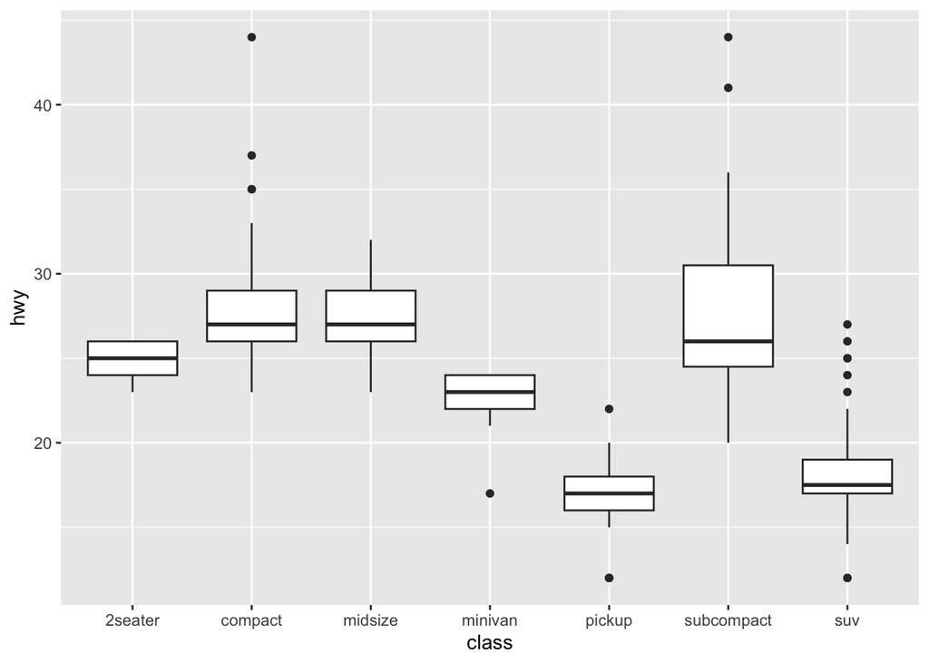

```r
ggplot(data = mpg) +
  geom_boxplot(mapping = aes(x = class, y = hwy))
```

Khi có nhiều nhóm, chúng ta có thể sử dụng boxplot nằm ngang để tiện hơn cho việc trình bày báo cáo. Bạn có thể làm điểu này bằng cách thay đổi x và y cho nhau, hoặc thêm hàm `coord_flip()` để xoay ngang biểu đồ.

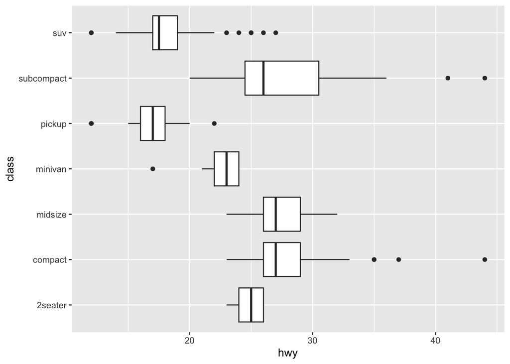

```r
# Cách 1
ggplot(data = mpg) +
  geom_boxplot(mapping = aes(x = hwy, y = class))
```

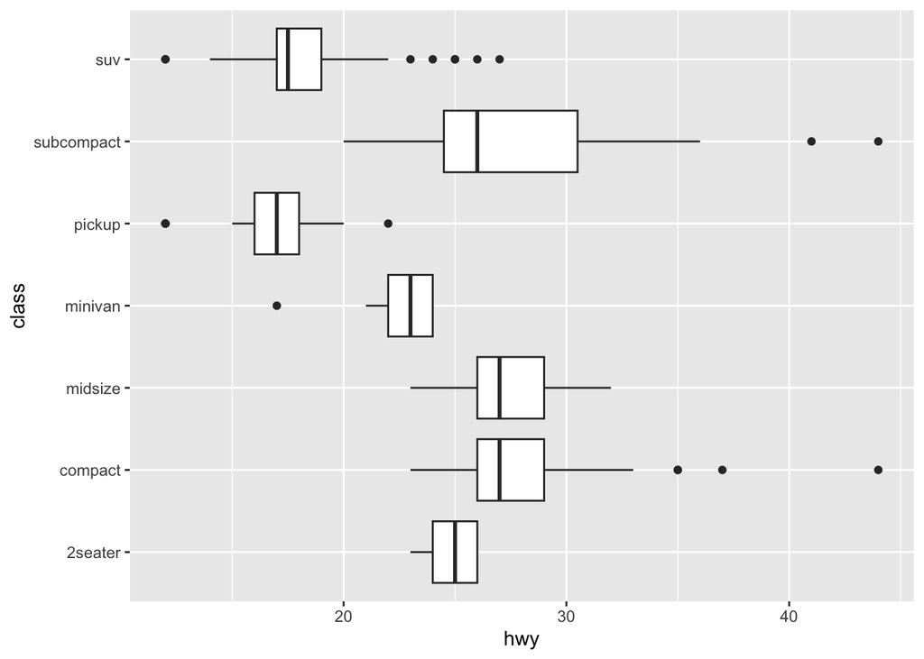

```r
# Cách 2
ggplot(data = mpg) +
  geom_boxplot(mapping = aes(x = class, y = hwy)) +
  coord_flip()
```

Các biểu đồ tương tự boxplot: `geom_dot()`, `geom_violin()`.